# SpASM

```r
knitr::opts_chunk$set(echo = F, eval = F)
```

This repo is an updated version of the GASP module developed for Ovando et al. 2016 Fish and Fisheries.

# Next ideas

```r
# demons::load_functions('../R')
# load("../data/lhi.rda")
library(tidyverse)
library(spasm)
library(stringr)
library(rfishbase)
library(modelr)
library(Rcpp)
library(RcppEigen)
library(viridis)
library(LBSPR)

# sourceCpp("scripts/eigen_mat_mult.cpp")

fish <- create_fish(adult_movement = 1e-3,
                    larval_movement = 1e-3,
                    density_dependence_form = 1,
                    price = 10,
                    query_fishbase = F,
                    linf = 100,
                    age_mature = 2,
                    vbk = .2,
                    t0 = 0,
                    min_age = 0,
                    max_age = 20,
                    time_step = 1,
                    weight_a = 1e-3,
                    weight_b = 3)


fleet <-
  create_fleet(
      eq_f = .2,
    length_50_sel = 50,
    delta = 2,
    fish = fish,
    mpa_reaction = 'concentrate',
    price = 1,
    cost = 1000,
    beta = 1.3,
    theta = 1e-1,
    q = 1e-3,
    fleet_model = 'open-access',
    effort_allocation = 'gravity',
    initial_effort = 10,
    target_catch = 1
  )
```

1. Make a “profit-gravity” model, where they distribute themselves by profits in each patch, allowing for heterogeneous costs in each patch

```r
fleet$effort_allocation <- 'profit-gravity'
fleet$fleet_model <- 'constant-effort'

tester <-
  sim_fishery(
    fish = fish,
    fleet = fleet,
    manager  = create_manager(mpa_size = 0, year_mpa = 10),
    num_patches = 1,
    burn_year = 25,
    sim_years = 50,
    enviro = sin(1:75),
    enviro_strength = 0.001,
    rec_driver = 'environment'
  )

tester %>%
  filter(age == min(age)) %>%
  ggplot(aes(year, numbers)) +
  geom_point()


tester %>%
  group_by(year, patch) %>%
  summarise(te = sum(effort, na.rm = T))
```

OK that works now. Now, add in ability to have cost vary by patch.

```r
fleet$cost_slope <-  0.1

fleet$cost_function <- 'distance from port'


tester <-
  sim_fishery(
    fish = fish,
    fleet = fleet,
    manager  = create_manager(mpa_size = 0, year_mpa = 10),
    num_patches = 2,
    burn_year = 25,
    sim_years = 10
  )


tester %>%
  group_by(year, patch) %>%
  summarise(te = sum(effort, na.rm = T))
```

2. Allow q to vary by time

```r
fleet$tech_rate <- 0.1

tester <-
  sim_fishery(
    fish = fish,
    fleet = fleet,
    manager  = create_manager(mpa_size = 0, year_mpa = 10),
    num_patches = 2,
    burn_year = 25,
    sim_years = 10
  )

tester %>%
  group_by(year) %>%
  summarise(tf = sum(f, na.rm = T))
```

4. Add in recruitment variability and autocorrelation

```r
fish$t0 <- -0.1

fish$sigma_r <- 0

fish$rec_ac <- 0

fleet$tech_rate <- 0.1

fleet$initial_effort <-  1000

tester <-
  sim_fishery(
    fish = fish,
    fleet = fleet,
    manager  = create_manager(mpa_size = 0, year_mpa = 10),
    num_patches = 2,
    burn_year = 25,
    sim_years = 10
  )

tester %>%
  filter(age == 1) %>%
  group_by(year) %>%
  summarise(tn = sum(numbers, na.rm = T)) %>%
  ggplot(aes(year, tn)) +
  geom_point()
```

5. Incorporate sampling of length structure into model

No need to do this in the model, you can sample from the numbers at age afterwords.

```r
n_at_age <- tester %>%
  filter(year == max(year)) %>%
  select(patch,age, numbers, numbers_caught)

length_samples <- sample_lengths(n_at_age = n_at_age,
                                 cv = 0.1,
                                 k = fish$vbk,
                                 linf = fish$linf,
                                 t0 = fish$t0,
                                 sample_type = 'catch',
                                 percent_sampled = 1,
                                 time_step = 1)

    length_samples %>%
      ggplot(aes(length_bin, numbers)) +
      geom_col()
```

And now, age those length samples.

```r
age_samples <- length_to_age(length_samples = length_samples,
                             cv = 0.1,
                             k = fish$vbk,
                             linf = fish$linf,
                             t0 = fish$t0,
                             max_age = fish$max_age,
                             min_age = fish$min_age,
                             time_step = fish$time_step)

age_samples$numbers %>% sum()

wtf <- tester %>% filter(year == max(year)) %>% select(age,patch,numbers_caught) %>%
  group_by(age) %>% summarise(numbers = sum(numbers_caught)) %>%
mutate(age_type = 'true')

sum(wtf$numbers)

age_samples %>%
  mutate(age_type = 'sampled') %>%
  bind_rows(wtf) %>%
  ggplot(aes(age,numbers, fill = age_type)) +
  geom_col(position = 'dodge')


tester %>%
  ggplot(aes(age,1 - exp(-f))) +
  geom_col(aes(fill = factor(patch)), position = 'dodge') +
  facet_wrap(~year)


tester %>%
  select(year,age,numbers, numbers_caught, patch) %>%
  gather('number_type','number',numbers:numbers_caught) %>%
  group_by(year, age,number_type) %>%
  summarise(tn = sum(number, na.rm = T)) %>%
  ggplot(aes(age,tn, fill = number_type)) +
  geom_col(position = 'dodge') +
  facet_wrap(~year)

tester %>%
  group_by(year,age) %>%
  summarise(numbers = sum(numbers)) %>%
  ggplot(aes(age,numbers)) +
  geom_col() +
  facet_wrap(~year)


tester %>%
  group_by(year,patch) %>%
  summarise(te = sum(effort)) %>%
  ggplot(aes(patch, te, color = factor(year))) +
  geom_line()
```

Bring it all on home

```r
fleet$cost_slope <-  0.1

fleet$cost_function <- 'distance from port'

fish$t0 <- -0.1

fish$sigma_r <- 0.75

fish$rec_ac <- 0

fleet$tech_rate <- 0.1

fleet$initial_effort <-  1000

fleet$effort_allocation <- 'profit-gravity'

fleet$fleet_model <- 'constant-effort'

fleet$price <-  100

fleet$cost <- 10

fleet$theta = 2e-3


tester <-
  sim_fishery(
    fish = fish,
    fleet = fleet,
    manager  = create_manager(mpa_size = 0, year_mpa = 10),
    num_patches = 10,
    burn_year = 25,
    sim_years = 10
  )

tester %>%
  group_by(year) %>%
  summarise(
    tb = sum(ssb),
    te = sum(effort),
            tp = sum(profits)) %>%
              ggplot(aes(tb, te)) +
              geom_path()
```

```r
tester %>%
  group_by(year, age) %>%
  summarise(tn = sum(numbers)) %>%
  ggplot(aes(age, tn, color = year)) +
  geom_line(position = 'dodge', alpha = 0.5, size = 1.5) +
  facet_grid(year ~ . , as.table = F) +
  theme_classic() +
  theme(axis.text.y = element_blank(),
        panel.spacing = unit(0,'cm'),
        strip.background = element_blank(),
        strip.text = element_blank()) +
  scale_color_viridis()
```

```r
tester %>%
  group_by(year,patch) %>%
  summarise(te = sum(effort)) %>%
  ggplot(aes(patch, te, color = factor(year))) +
  geom_line()
```

check length sampling

```r
n_at_age <- tester %>%
  filter(year == max(year)) %>%
  select(patch,age, numbers, numbers_caught)

length_samples <- sample_lengths(n_at_age = n_at_age,
                                 cv = 0.1,
                                 k = fish$vbk,
                                 linf = fish$linf,
                                 t0 = fish$t0,
                                 sample_type = 'catch',
                                 percent_sampled = 1,
                                 time_step = fish$time_step)

    length_samples %>%
      ggplot(aes(length_bin, numbers)) +
      geom_col()
```

```r
length_samples <- tester %>%
  select(year,patch,age, numbers, numbers_caught) %>%
  nest(-year) %>%
  mutate(length_samples = map(data, ~sample_lengths(n_at_age = .x,
                                                   cv = 0.1,
                                                    k = fish$vbk,
                                 linf = fish$linf,
                                 t0 = fish$t0,
                                 sample_type = 'catch',
                                 percent_sampled = 1,
                                 fish$time_step))) %>%
  select(-data) %>%
  unnest()


length_samples %>%
  ggplot(aes(length_bin, numbers, color = year)) +
  geom_line(position = 'dodge', alpha = 0.5, size = 1.5) +
  facet_grid(year ~ . , as.table = F) +
  theme_classic() +
  theme(axis.text.y = element_blank(),
        panel.spacing = unit(0,'cm'),
        strip.background = element_blank(),
        strip.text = element_blank()) +
  scale_color_viridis()
```

check age sampling

```r
    age_samples <- length_to_age(length_samples = length_samples,
                             cv = 0.1,
                             k = fish$vbk,
                             linf = fish$linf,
                             t0 = fish$t0,
                             max_age = fish$max_age,
                             min_age = fish$min_age,
                             time_step = fish$time_step)

age_samples %>%
  mutate(age_type = 'sampled') %>%
  bind_rows(wtf) %>%
  ggplot(aes(age,numbers, fill = age_type)) +
  geom_col(position = 'dodge')


tester %>%
  ggplot(aes(age,1 - exp(-f))) +
  geom_col(aes(fill = factor(patch)), position = 'dodge') +
  facet_wrap(~year)


tester %>%
  select(year,age,numbers, numbers_caught, patch) %>%
  gather('number_type','number',numbers:numbers_caught) %>%
  group_by(year, age,number_type) %>%
  summarise(tn = sum(number, na.rm = T)) %>%
  ggplot(aes(age,tn, fill = number_type)) +
  geom_col(position = 'dodge') +
  facet_wrap(~year)

tester %>%
  group_by(year,age) %>%
  summarise(numbers = sum(numbers)) %>%
  ggplot(aes(age,numbers)) +
  geom_col() +
  facet_wrap(~year)
```

This is a scotch project at home

# What the hell is going on

I can’t convince myself that the hockey stick in mortality isn’t a big somehow. So, how to debug this.

1. Create an artificial spike in the F rates and see if it propogates perfectly through the age structure
2. Write out a simple little loop population and test it that way
3. Track the mortality it each cohort in the model itself and predict it.
4. Check for a normal bug again.

```r
fish <- create_fish(adult_movement = 1e-3,
                    larval_movement = 1e-3,
                    density_dependence_form = 1,
                    price = 10,
                    query_fishbase = F,
                    linf = 65,
                    vbk = .2,
                    t0 = -0.01,
                    cv_len = 0.2,
                    length_mature =  34,
                    m = 0.2,
                    min_age = 0,
                    max_age = floor(-log(0.01) / 0.2),
                    time_step = 1,
                    weight_a = 0.0245,
                    weight_b = 2.79,
                    sigma_r = 0,
                    rec_ac = 0)

fleet <-
  create_fleet(
    length_50_sel = 0.25*fish$linf,
    delta = 1,
    fish = fish,
    mpa_reaction = 'concentrate',
    price = 1,
    cost = 1000,
    beta = 1.3,
    theta = 1e-1,
    q = 1e-3,
    fleet_model = 'constant-effort',
    effort_allocation = 'simple',
    initial_effort = 0,
    target_catch = 0
  )


fish$rec_ac <- 0

fish$sigma_r <- 0

fish$cv_len <- 0

fish$m <- 0.1

fish$max_age <- 100

fish <- update_fish(fish)

fleet$length_50_sel <- 0* fish$linf

fleet$initial_effort <- 200

fleet <- update_fleet(fleet, fish)

  cc_fishery <- sim_fishery(fish = fish, fleet = fleet,
    manager  = create_manager(mpa_size = 0, year_mpa = 10),
    num_patches = 1,
    burn_year = 30,
    sim_years = 70
  )



test_data <- cc_fishery %>%
  ungroup() %>%
  filter(year == max(year)) %>%
  group_by(age) %>%
  summarise(numbers = sum(numbers)) %>%
  mutate(log_numbers = log(numbers)) %>%
  ungroup()

peak_age <- test_data$age[test_data$numbers == max(test_data$numbers)]

cc <- lm(log_numbers ~ age, data = test_data)

summary(cc)

cc_fishery$f %>% unique() + fish$m

test_data %>%
  ggplot(aes(age, log_numbers)) +
  geom_point()
```

```r
n_mat <- matrix(NA, nrow = 20, ncol = 20)

n_mat[,1] <-  100

n_mat[1,] <-  100 * exp(-.1 * 0:19)

 fs <-  c(rep(.1,10), rep(.8,10))

 fs <- rlnorm(20, log(.2),2)

for (t in 2:20){

  n_mat[t,2:20] <- n_mat[t - 1,1:19] * exp(-fs[t])

  }

wtf <- n_mat[20,] %>% log()

data_frame(a = wtf, b = lead(wtf,1)) %>%
  mutate(survival = b - a,
         fs = rev((-fs)))

plot(wtf)
```

And duh, it doesn’t work perfectly once you throw in a recruitment function since it’s no longer a constant input, at least until it hits equilibirum. So, you’re putting in less fish, which makes the survival rate actually a bit higher than you’d think, since there are proportionally more older fish than under constant recruitment

# Test assessment modules

A catch curve

```r
fish <- create_fish(adult_movement = 1e-3,
                    larval_movement = 1e-3,
                    density_dependence_form = 1,
                    price = 10,
                    query_fishbase = F,
                    linf = 65,
                    vbk = .2,
                    t0 = -0.01,
                    cv_len = 0,
                    length_50_mature  =  37,
                    length_95_mature = 38,
                    m = 0.2,
                    min_age = 0,
                    max_age = floor(-log(0.01) / fish$m),
                    time_step = 0.25,
                    weight_a = 0.0245,
                    weight_b = 2.79,
                    sigma_r = 0,
                    rec_ac = 0)

fleet <-
  create_fleet(
    length_50_sel = 0.25*fish$linf,
    delta = 1,
    fish = fish,
    mpa_reaction = 'concentrate',
    price = 1,
    cost = 1000,
    beta = 1.3,
    theta = 1e-1,
    q = 1e-3,
    fleet_model = 'constant-effort',
    effort_allocation = 'simple',
    initial_effort = 0,
    target_catch = 0
  )


fish$rec_ac <- 0

fish$sigma_r <- 0

fish$cv_len <- 0.1

fish$max_age <- ((-log(0.01)/fish$m)/fish$time_step) %>% floor()

fish <- update_fish(fish)

fleet$length_50_sel <- 0.5* fish$linf

fleet$initial_effort <- 50

fleet <- update_fleet(fleet, fish)

  cc_fishery <- sim_fishery(fish = fish, fleet = fleet,
    manager  = create_manager(mpa_size = 0, year_mpa = 10),
    num_patches = 1,
    burn_year = 100,
    sim_years = 300
  )


n_at_age <- cc_fishery %>%
  filter(year == max(year)) %>%
  select(patch,age, numbers, numbers_caught)

length_samples <- sample_lengths(n_at_age = n_at_age,
                                 cv = fish$cv_len,
                                 k = fish$vbk,
                                 linf = fish$linf,
                                 t0 = fish$t0,
                                 sample_type = 'catch',
                                 percent_sampled = 1,
                                 time_step = fish$time_step) %>%
  mutate(year = 1)

z <- run_catch_curve(length_comps = length_samples, fish = fish)
z
mean(cc_fishery$f) + fish$m
```

OK so it’s not that, the length resampling works

LBSPR

```r
lbspr_fish <-  new("LB_pars")

lbspr_fish@Species <- 'WTF'

lbspr_fish@Linf <- fish$linf

lbspr_fish@M <- fish$m

lbspr_fish@MK <- fish$m / fish$vbk

lbspr_fish@Steepness <- fish$steepness

# lbspr_fish@CVLinf <- fish$cv_len

lbspr_fish@L50 <- fish$length_50_mature

lbspr_fish@L95 <- fish$length_95_mature

lbspr_fish@Walpha <- fish$weight_a
#
lbspr_fish@Wbeta <- fish$weight_b

lbspr_fish@SL50 <- fleet$length_50_sel

lbspr_fish@SL95 <- fleet$length_50_sel + fleet$delta

lbspr_fish@FM <- mean(cc_fishery$f) / fish$m

lbspr_fish@BinWidth <- 1

lbspr_fish@L_units <- 'cm'

lbspr_sim <- LBSPRsim(lbspr_fish, Control = list(modtype = 'absel', Nage = fish$max_age / fish$time_step))

plotSim(lbspr_sim)

lbspr_lengths <- new("LB_lengths", LB_pars=lbspr_fish, dataType = 'freq')

lbspr_lens <- length_samples %>%
  spread(year,numbers) %>%
  mutate(length_bin = length_bin + 0.5) %>%
  rename(LMids = length_bin) %>%
  as.matrix()

  lbspr_lengths@LData <- lbspr_lens[,-1] %>% as.matrix()

  lbspr_lengths@LMids <- lbspr_lens[,1] %>% as.numeric()

  lbspr_lengths@NYears <- ncol(lbspr_lens) - 1 # - 1

  lbspr_lengths@Years <- 1:lbspr_lengths@NYears

  lbspr_fit <- LBSPRfit(lbspr_fish, lbspr_lengths,Control = list(modtype = 'absel', Nage = fish$max_age / fish$time_step))

  a = fit_lbspr(fish = fish, fleet = fleet, length_comps = length_samples)
```

```r
plotSize(lbspr_fit)

lbspr_fit@SL95
```

So close!!!

Let’s do one more check and see if you get the same unfished population

# Checking on selectivity

It seems like something is going wrong in the length sampling; the length comps don’t seem to be matching selecitivity.

```r
fish$time_step <- 0.25

fish <- update_fish(fish)

fleet$length_50_sel

fleet$initial_effort <- 100

fleet <- update_fleet(fleet = fleet, fish = fish)
check <- sim_sampling(fish = fish, fleet = fleet, percent_sampled = 1)

check <- check %>%
  filter(year == max(year))

length_comps <- check %>%
  select(catch_length_samples) %>%
  unnest() %>%
  mutate(year = 1)

check %>%
select(n_at_age) %>%
  unnest() %>%
  mutate(sel = fleet$sel_at_age,
         mean_length = fish$length_at_age) %>%
  ggplot(aes(age,numbers_caught, fill = sel)) +
  geom_point(shape = 21)
```

So that looks good, so I’m guessing that there’s a problem in the conversion from age to length in the length sampling.

```r
check %>%
select(catch_ages_samples) %>%
  unnest() %>%
  mutate(sel = fleet$sel_at_age,
         mean_length = fish$length_at_age) %>%
  ggplot(aes(age,numbers, fill = sel)) +
  geom_point(shape = 21)
```

```r
check %>%
select(catch_length_samples) %>%
  unnest() %>%
  ggplot(aes(length_bin,numbers)) +
  geom_point(shape = 21) +
  geom_vline(aes(xintercept = fleet$length_50_sel))
```

```r
lbspr_fish <-  new("LB_pars")

lbspr_fish@Species <- 'WTF'

lbspr_fish@Linf <- fish$linf

lbspr_fish@M <- fish$m

lbspr_fish@MK <- fish$m / fish$vbk

lbspr_fish@Steepness <- fish$steepness

# lbspr_fish@CVLinf <- fish$cv_len

lbspr_fish@L50 <- fish$length_50_mature

lbspr_fish@L95 <- fish$length_95_mature

lbspr_fish@Walpha <- fish$weight_a
#
lbspr_fish@Wbeta <- fish$weight_b

lbspr_fish@SL50 <- fleet$length_50_sel

lbspr_fish@SL95 <- fleet$length_50_sel + fleet$delta

lbspr_fish@FM <- mean(check$fishery[[1]]$f) / fish$m

lbspr_fish@BinWidth <- 1

lbspr_fish@L_units <- 'cm'


lbspr_sim <- LBSPRsim(lbspr_fish, Control = list(modtype = 'absel', Nage = 100)) #fish$max_age / fish$time_step - 25))


spasm_lengths <- check %>%
  filter(year == max(year)) %>%
  select(pop_length) %>%
  unnest() %>%
  mutate(source = 'spasm')

lbspr_lengths <- lbspr_sim@pLPop %>%
  as_data_frame() %>%
  select(LMids, PopUF) %>%
  rename(length_bin = LMids,numbers = PopUF) %>%
  mutate(source = 'lbspr')

comp_lengths <- spasm_lengths %>%
  bind_rows(lbspr_lengths) %>%
  group_by(source) %>%
  mutate(pnumbers = numbers / sum(numbers))

comp_lengths %>%
  ggplot(aes(length_bin, pnumbers, fill = source)) +
  geom_point(shape = 21) +
  geom_vline(data = data_frame(lata = fish$length_at_age %>% floor()), aes(xintercept =lata))
```

```r
  a = fit_lbspr(fish = fish, fleet = fleet, length_comps = length_comps)
a
check$fishery[[1]]$f %>% unique() / fish$m
```

AHA. Setting Nage to max_age + 2 seems to do the trick, probably to account for the fact that you don’t have a zero, plus some other goofiness.

So the last question, why the hell aren’t the distributions perfectly centered on the mean length_at_age values?, ah not a problem, just an artifact of Geom_col

# Move to flexible time

```r
fish <- create_fish(adult_movement = 1e-3,
                    larval_movement = 1e-3,
                    density_dependence_form = 1,
                    price = 10,
                    query_fishbase = F,
                    linf = 100,
                    age_mature = 2,
                    vbk = .2,
                    t0 = -0.01,
                    min_age = 0,
                    max_age = 20,
                    time_step = 1,
                    weight_a = 1e-3,
                    weight_b = 3)


fleet <-
  create_fleet(
      eq_f = .2,
    length_50_sel = 50,
    delta = 2,
    fish = fish,
    mpa_reaction = 'concentrate',
    price = 1,
    cost = 1000,
    beta = 1.3,
    theta = 1e-1,
    q = 1e-3,
    fleet_model = 'open-access',
    effort_allocation = 'gravity',
    initial_effort = 10,
    target_catch = 1
  )

fleet$effort_allocation <- 'profit-gravity'
fleet$fleet_model <- 'constant-effort'

tester <-
  sim_fishery(
    fish = fish,
    fleet = fleet,
    manager  = create_manager(mpa_size = 0, year_mpa = 10),
    num_patches = 1,
    burn_year = 25,
    sim_years = 50
  )
```

THE CONCENSUS. lbspr is useless for estimating things from other operating models, unless you happen to perfectly tune nage manually. Give up on it for now, spend the rest of the flight showing a simple F and SPR calculation given knowledge of selectivity. LBSPR may be useful for real data, but this actually calls that into question for me. The world you’re simulating might be less common, but it’s not insane, and it’s troubling that LBSPR can’t replicate it at all. This operating model should just be a special case of the broader world of possible scenarios, and LBSPR should be able to pick it up if it’s working correctly.

# Issues with aging

There’s a slight problem with the age conversions at large lengths. For very small growth increments, multiple age classess fall within one length bin, where a length bin is only 1cm. So, the numbers in that bin then get smoothed out over the ages. Not a big deal, but it’s somethimg

# scrooge support

So what you’re up to now is a) making sure that spasm still works and b) get the economic indicators up and running. Once you’ve done that, you can also revisit your length comp generation and sampling. Eventually I’d kind of like to add in the growth-type-groups thing

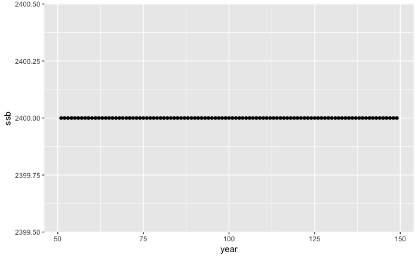

```r
library(spasm)
library(tidyverse)
fish <- spasm::create_fish(linf = 100)
fleet <- spasm::create_fleet(fish = fish)
manager <- spasm::create_manager(mpa_size = 0)
sim <- spasm::sim_fishery(fish = fish,
                   fleet = fleet,
                   manager = manager,
                   num_patches = 1,
                   sim_years = 100,
                   burn_year = 50)
sim %>%
  group_by(year) %>%
  summarise(ssb = sum(effort)) %>%
  ggplot(aes(year, ssb)) +
  geom_line() +
  geom_point()
```

sweet, that thing still works and looks about right.

Now let’s see if open access as it is currently defined still works

[figure not shown]

OK, looks like that works for all the basic functional forms, need to check on supplied catch sometime but that’s a problem for another day.